```r
setwd("C:/Users/adaba/Documents/Coursera/Credit Card Approval")
library(data.table)
```

Let’s read in the credit data

```r
crx.data <- data.table(read.table("data/crx.data.txt", header = FALSE, sep = ",", na.strings = "?"))
```

Lets preview our credit data

```r
head(crx.data)
```

```
##    V1    V2    V3 V4 V5 V6 V7   V8 V9 V10 V11 V12 V13 V14 V15 V16
## 1:  b 30.83 0.000  u  g  w  v 1.25  t   t   1   f   g 202   0   +
## 2:  a 58.67 4.460  u  g  q  h 3.04  t   t   6   f   g  43 560   +
## 3:  a 24.50 0.500  u  g  q  h 1.50  t   f   0   f   g 280 824   +
## 4:  b 27.83 1.540  u  g  w  v 3.75  t   t   5   t   g 100   3   +
## 5:  b 20.17 5.625  u  g  w  v 1.71  t   f   0   f   s 120   0   +
## 6:  b 32.08 4.000  u  g  m  v 2.50  t   f   0   t   g 360   0   +
```

It is good to have an idea about the class of the variables, their levels and some sample data

```r
str(crx.data)
```

```
## Classes 'data.table' and 'data.frame':   690 obs. of  16 variables:
##  $ V1 : Factor w/ 2 levels "a","b": 2 1 1 2 2 2 2 1 2 2 ...
##  $ V2 : num  30.8 58.7 24.5 27.8 20.2 ...
##  $ V3 : num  0 4.46 0.5 1.54 5.62 ...
##  $ V4 : Factor w/ 3 levels "l","u","y": 2 2 2 2 2 2 2 2 3 3 ...
##  $ V5 : Factor w/ 3 levels "g","gg","p": 1 1 1 1 1 1 1 1 3 3 ...
##  $ V6 : Factor w/ 14 levels "aa","c","cc",..: 13 11 11 13 13 10 12 3 9 13 ...
##  $ V7 : Factor w/ 9 levels "bb","dd","ff",..: 8 4 4 8 8 8 4 8 4 8 ...
##  $ V8 : num  1.25 3.04 1.5 3.75 1.71 ...
##  $ V9 : Factor w/ 2 levels "f","t": 2 2 2 2 2 2 2 2 2 2 ...
##  $ V10: Factor w/ 2 levels "f","t": 2 2 1 2 1 1 1 1 1 1 ...
##  $ V11: int  1 6 0 5 0 0 0 0 0 0 ...
##  $ V12: Factor w/ 2 levels "f","t": 1 1 1 2 1 2 2 1 1 2 ...
##  $ V13: Factor w/ 3 levels "g","p","s": 1 1 1 1 3 1 1 1 1 1 ...
##  $ V14: int  202 43 280 100 120 360 164 80 180 52 ...
##  $ V15: int  0 560 824 3 0 0 31285 1349 314 1442 ...
##  $ V16: Factor w/ 2 levels "-","+": 2 2 2 2 2 2 2 2 2 2 ...
##  - attr(*, ".internal.selfref")=<externalptr>
```

Lets see the full column names in our credit data set

```r
names(crx.data)
```

```
##  [1] "V1"  "V2"  "V3"  "V4"  "V5"  "V6"  "V7"  "V8"  "V9"  "V10" "V11"
## [12] "V12" "V13" "V14" "V15" "V16"
```

Let’s examine the distribution of the target variable, the one we are trying to predict to view , the distribution, we will convert the values to numeric values for this purpose We saw that the target variables values were “+” and “-”, hence in our conversions, the “+” = 1 and “-”" = 0

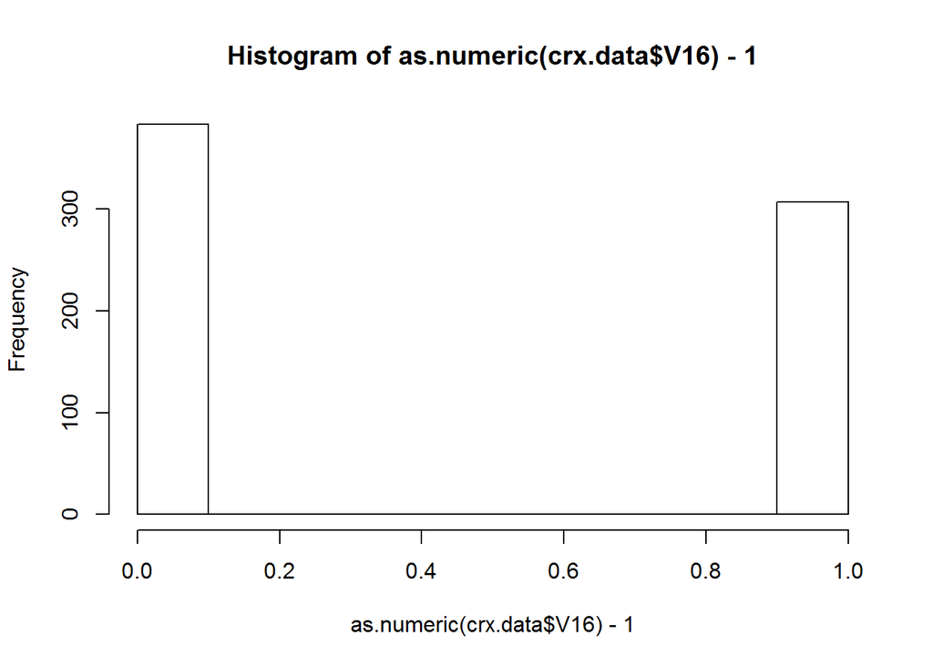

```r
hist(as.numeric(crx.data$V16)-1)
```

Lets see how are target variable now looks

```r
as.numeric(crx.data$V16)-1
```

```
##   [1] 1 1 1 1 1 1 1 1 1 1 1 1 1 1 1 1 1 1 1 1 1 1 1 1 1 1 1 1 1 1 1 1 1 1 1
##  [36] 1 1 1 1 1 1 1 1 1 1 1 1 1 1 1 1 1 1 1 1 1 1 1 1 1 1 1 1 1 1 1 1 1 1 1
##  [71] 0 0 0 0 0 0 0 0 0 0 0 0 0 0 0 0 0 0 0 0 0 0 0 0 0 0 0 0 0 0 0 0 0 0 0
## [106] 0 0 0 0 0 0 0 0 0 0 0 0 1 1 1 1 1 1 1 1 1 1 1 1 1 1 1 1 1 1 1 1 1 1 1
## [141] 1 1 1 1 1 1 1 1 1 1 1 1 1 1 1 1 1 1 1 1 1 1 1 1 1 1 1 1 1 1 1 1 1 1 1
## [176] 1 1 1 1 1 1 1 1 1 1 1 1 1 1 1 1 1 1 1 1 1 1 1 1 1 1 1 1 1 1 1 1 1 1 1
## [211] 1 1 1 1 1 1 1 1 1 1 1 1 1 1 1 1 1 1 1 1 1 1 1 1 1 1 1 1 1 1 1 1 1 1 1
## [246] 1 1 1 1 1 1 1 1 1 0 0 0 0 0 0 0 0 0 0 0 0 0 0 1 1 1 0 0 0 0 0 0 0 0 0
## [281] 0 0 0 0 0 0 0 0 0 0 0 0 0 0 0 0 0 0 0 0 0 0 0 0 0 0 0 0 0 0 0 0 0 0 0
## [316] 0 0 1 1 1 1 1 1 1 0 0 0 0 0 0 0 0 0 0 0 0 0 0 0 0 0 0 0 0 0 0 0 0 0 0
## [351] 0 0 0 0 0 0 0 0 0 0 0 0 0 0 0 0 0 0 0 0 0 0 0 0 0 0 0 0 0 0 0 0 0 0 0
## [386] 0 0 0 0 0 0 0 0 0 0 0 0 0 0 0 0 0 0 0 0 0 0 0 0 0 0 0 0 0 0 0 0 0 0 0
## [421] 0 0 0 0 0 0 0 0 0 0 0 0 0 0 0 0 0 0 0 0 0 0 0 0 0 0 0 0 0 0 0 0 0 0 0
## [456] 0 0 0 0 0 0 0 0 0 0 0 0 0 0 0 0 0 0 0 0 0 0 0 0 0 0 0 0 0 0 0 0 0 0 0
## [491] 1 1 1 1 1 1 1 1 1 1 1 1 1 1 1 1 1 1 1 1 1 1 1 1 1 1 1 1 1 1 1 1 1 0 0
## [526] 0 0 0 0 0 0 0 0 0 0 0 0 0 0 0 0 0 0 0 0 0 0 1 1 1 1 1 1 1 1 1 1 1 1 1
## [561] 1 1 1 1 1 1 1 1 1 1 1 1 1 1 1 1 1 1 1 1 1 1 1 1 1 1 1 1 1 1 1 1 1 1 1
## [596] 1 1 1 1 1 1 0 0 0 0 0 1 0 0 0 0 0 0 0 0 0 0 0 0 0 0 1 1 0 0 0 0 0 0 0
## [631] 0 0 0 0 0 0 0 0 0 0 0 0 0 0 0 0 0 0 0 0 0 0 0 0 0 0 0 0 0 0 0 0 0 0 0
## [666] 0 0 0 0 0 0 0 0 0 0 0 0 0 0 0 0 0 0 0 0 0 0 0 0 0
```

Lets now actually change the target variable to 0s and 1s in our dataset for the rest of the analysis

```r
crx.data$V16 <- as.numeric(crx.data$V16)-1
```

Lets create check the distribution of each of the attributes of the credit data using histograms

```r
numeric_data <- as.data.frame(crx.data[,c(2,3,8,11,14,15)])
summary(numeric_data)
```

```
##        V2              V3               V8              V11
##  Min.   :13.75   Min.   : 0.000   Min.   : 0.000   Min.   : 0.0
##  1st Qu.:22.60   1st Qu.: 1.000   1st Qu.: 0.165   1st Qu.: 0.0
##  Median :28.46   Median : 2.750   Median : 1.000   Median : 0.0
##  Mean   :31.57   Mean   : 4.759   Mean   : 2.223   Mean   : 2.4
##  3rd Qu.:38.23   3rd Qu.: 7.207   3rd Qu.: 2.625   3rd Qu.: 3.0
##  Max.   :80.25   Max.   :28.000   Max.   :28.500   Max.   :67.0
##  NA's   :12
##       V14            V15
##  Min.   :   0   Min.   :     0.0
##  1st Qu.:  75   1st Qu.:     0.0
##  Median : 160   Median :     5.0
##  Mean   : 184   Mean   :  1017.4
##  3rd Qu.: 276   3rd Qu.:   395.5
##  Max.   :2000   Max.   :100000.0
##  NA's   :13
```

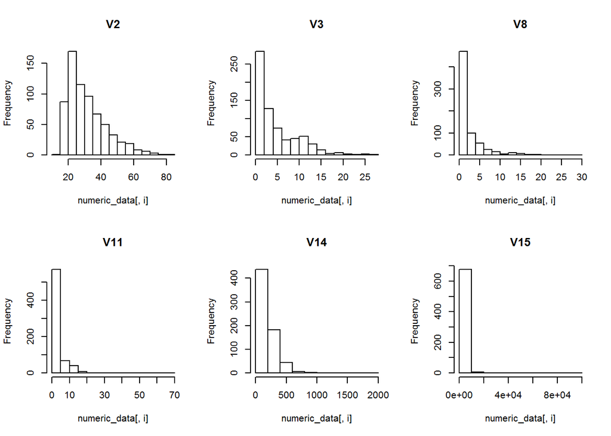

```r
par(mfrow=c(2,3))
for(i in 1:6) {
    hist(numeric_data[,i], main=names(numeric_data)[i])
}
```

The variable V2 seems to have bell curve shape but most of the numeric variables of our dataset are skewed to the right ( their tails point to the right). This suggests we can preprocess or transform the data using techniques like Box-Cox to see if it enhances the model performance after our first model built. (However, we will not be covering that technique in this article)

A closer look at variable V14 particularly V15 (and also deducing from the summary statistics indicate there might be some outliers . For instance, the average of the V15 variable is 1017.4 whereas the maximum is 100000.0 which is way from the normal. There advanced techniques to statistically detect outliers (That is not covered here) and we will not be removing these data points in this analysis

Lets take a closer look at V15 again

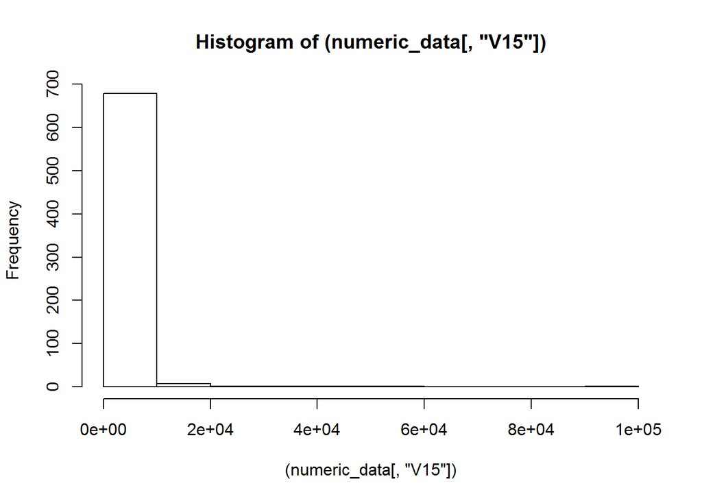

```r
par(mfrow=c(1,1))
hist((numeric_data[,"V15"]))
```

```r
#hist(log10(numeric_data[,"V15"]))
summary(numeric_data$V15)
```

```
##     Min.  1st Qu.   Median     Mean  3rd Qu.     Max.
##      0.0      0.0      5.0   1017.0    395.5 100000.0
```

lets look at the non numerical values to have a sense of how they are distributed

```r
non_numeric <- numeric_data <- as.data.frame(crx.data[,-c(2,3,8,11,14,15)])
```

How many are there?

```r
dim(non_numeric)
```

```
## [1] 690  10
```

What are they ?

```r
names(non_numeric)
```

```
##  [1] "V1"  "V4"  "V5"  "V6"  "V7"  "V9"  "V10" "V12" "V13" "V16"
```

Lets see their distribution. V16 was a factor variable but that was later converted to numeric. but we will view it as part of this distribution

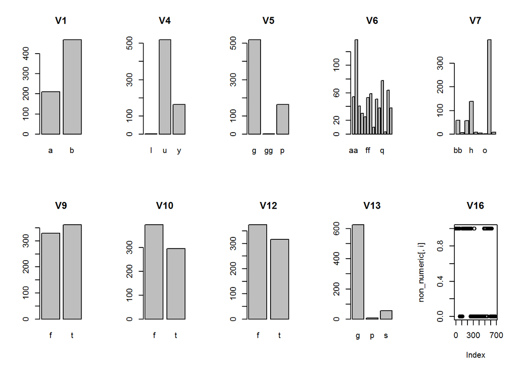

```r
par(mfrow=c(2,5))
for(i in 1:10) {
    plot(non_numeric[,i], main=names(non_numeric)[i])
}
```

Lets examine the relationship between the numerical features of the application

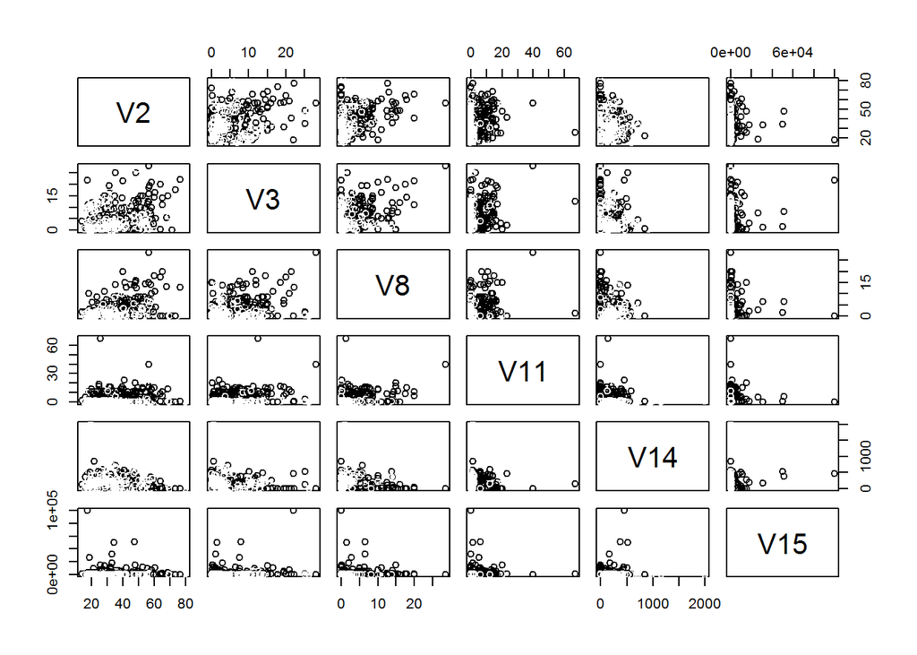

```r
plot(crx.data[,c(2,3,8,11,14,15)], col=crx.data$V16)
```

Lets check the correlations between the numerical features

```r
correlations <- cor(crx.data[,c(2,3,8,11,14,15)])
print(correlations)
```

```
##     V2        V3         V8        V11 V14        V15
## V2   1        NA         NA         NA  NA         NA
## V3  NA 1.0000000 0.29890156 0.27120674  NA 0.12312115
## V8  NA 0.2989016 1.00000000 0.32232967  NA 0.05134493
## V11 NA 0.2712067 0.32232967 1.00000000  NA 0.06369244
## V14 NA        NA         NA         NA   1         NA
## V15 NA 0.1231212 0.05134493 0.06369244  NA 1.00000000
```

lets get a pairwise visualization of all the dataset

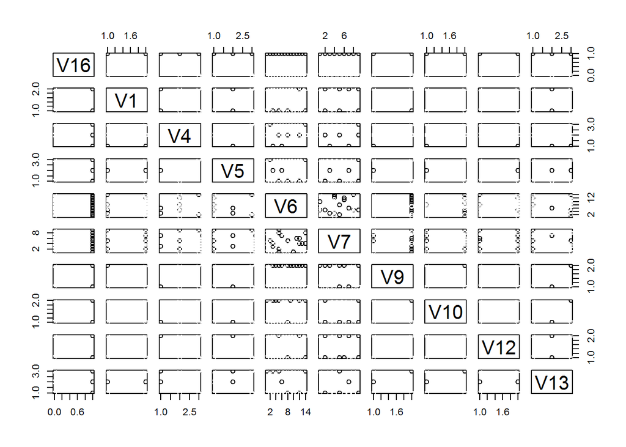

```r
pairs(V16~., data=non_numeric, col=non_numeric$V16)
```

summary

```r
summary(crx.data)
```

```
##     V1            V2              V3            V4         V5
##  a   :210   Min.   :13.75   Min.   : 0.000   l   :  2   g   :519
##  b   :468   1st Qu.:22.60   1st Qu.: 1.000   u   :519   gg  :  2
##  NA's: 12   Median :28.46   Median : 2.750   y   :163   p   :163
##             Mean   :31.57   Mean   : 4.759   NA's:  6   NA's:  6
##             3rd Qu.:38.23   3rd Qu.: 7.207
##             Max.   :80.25   Max.   :28.000
##             NA's   :12
##        V6            V7            V8         V9      V10
##  c      :137   v      :399   Min.   : 0.000   f:329   f:395
##  q      : 78   h      :138   1st Qu.: 0.165   t:361   t:295
##  w      : 64   bb     : 59   Median : 1.000
##  i      : 59   ff     : 57   Mean   : 2.223
##  aa     : 54   j      :  8   3rd Qu.: 2.625
##  (Other):289   (Other): 20   Max.   :28.500
##  NA's   :  9   NA's   :  9
##       V11       V12     V13          V14            V15
##  Min.   : 0.0   f:374   g:625   Min.   :   0   Min.   :     0.0
##  1st Qu.: 0.0   t:316   p:  8   1st Qu.:  75   1st Qu.:     0.0
##  Median : 0.0           s: 57   Median : 160   Median :     5.0
##  Mean   : 2.4                   Mean   : 184   Mean   :  1017.4
##  3rd Qu.: 3.0                   3rd Qu.: 276   3rd Qu.:   395.5
##  Max.   :67.0                   Max.   :2000   Max.   :100000.0
##                                 NA's   :13
##       V16
##  Min.   :0.0000
##  1st Qu.:0.0000
##  Median :0.0000
##  Mean   :0.4449
##  3rd Qu.:1.0000
##  Max.   :1.0000
##
```

What percentage of the dataset is missing some VALUES. if more than 10% we should go and find more and appropriate data Will this percentage of missen data have an impact on our ? How do we handle missen data ?

```r
missen <- sum(!complete.cases(crx.data))/dim(crx.data)[1] *100
missen
```

```
## [1] 5.362319
```

This shows about 5.36% missen data

**HANDLING MISSEN VALUES**

Input the missen values in the variable 1 (V1) with the most occuring value - MODE The list of variables are few hence we will be inputing the missen values one after the other. Ideally, you would a create function that will shorten the entire process.

Create function to get the mode

```r
getmode <- function(v) {
    uniqv <- unique(v)
    uniqv[which.max(tabulate(match(v, uniqv)))]
}
```

```r
v1.mode <- getmode(crx.data$V1)
```

Input the missen values with the mode

```r
crx.data[is.na(crx.data$V1), 1]  <- v1.mode
```

Preview the inputation

```r
table(crx.data$V1)
```

```
##
##   a   b
## 210 480
```

Input the missen values in the variable V2 with the average

```r
crx.data[is.na(crx.data$V2),  2]  <- mean(crx.data$V2, na.rm = TRUE)
```

Preview the inputation

```r
summary(crx.data$V2)
```

```
##    Min. 1st Qu.  Median    Mean 3rd Qu.    Max.
##   13.75   22.67   28.62   31.57   37.71   80.25
```

Input the missen values in the V4 with the mode

```r
crx.data[is.na(crx.data$V4), 4]  <- getmode(crx.data$V4)
#preview the inputation
table(crx.data$V4)
```

```
##
##   l   u   y
##   2 525 163
```

Input the missen values in the V5 with the mode

```r
crx.data[is.na(crx.data$V5), 5]  <- getmode(crx.data$V5)
#preview the inputation
table(crx.data$V5)
```

```
##
##   g  gg   p
## 525   2 163
```

V6: input the missen values with the mode

```r
crx.data[is.na(crx.data$V6), 6]  <- getmode(crx.data$V6)
#preview the inputation
table(crx.data$V6)
```

```
##
##  aa   c  cc   d   e  ff   i   j   k   m   q   r   w   x
##  54 146  41  30  25  53  59  10  51  38  78   3  64  38
```

Any missen values

```r
table(is.na(crx.data$V6))
```

```
##
## FALSE
##   690
```

V7: input the missen values with the mode

```r
crx.data[is.na(crx.data$V7), 7]  <- getmode(crx.data$V7)
#preview the inputation
table(crx.data$V7)
```

```
##
##  bb  dd  ff   h   j   n   o   v   z
##  59   6  57 138   8   4   2 408   8
```

```r
crx.data[is.na(crx.data$V14), 14]  <- as.integer(mean(crx.data$V14, na.rm = TRUE))
#preview the inputation
summary(crx.data$v14)
```

```
## Length  Class   Mode
##      0   NULL   NULL
```

Lets call the mlbench and caret libraries. You can install them if they are not already installed.

```r
#install.packages("mlbench")
#install.packages("caret")
library(mlbench)
library(caret)
```

Split data into test and train set Define an 70%/30% train/test split of the dataset

```r
set.seed(257)
trainIndex <- createDataPartition(crx.data$V16, p=0.70, list=FALSE)
dataTrain <- crx.data[ trainIndex,]
dataTest <- crx.data[-trainIndex,]
```

Run logistic regression on the training dataset

```r
model <- glm(V16 ~.,family=binomial(link='logit'),data=dataTrain)
```

Lets see the summary of our model results

```r
summary(model)
```

```
##
## Call:
## glm(formula = V16 ~ ., family = binomial(link = "logit"), data = dataTrain)
##
## Deviance Residuals:
##     Min       1Q   Median       3Q      Max
## -2.4383  -0.3272  -0.1221   0.4432   3.3254
##
## Coefficients: (2 not defined because of singularities)
##               Estimate Std. Error z value Pr(>|z|)
## (Intercept) -4.243e+00  2.058e+03  -0.002 0.998355
## V1b         -2.702e-01  3.618e-01  -0.747 0.455196
## V2           1.543e-02  1.524e-02   1.012 0.311384
## V3          -1.895e-02  3.193e-02  -0.594 0.552808
## V4u          1.338e-01  2.058e+03   0.000 0.999948
## V4y         -3.783e-01  2.058e+03   0.000 0.999853
## V5gg                NA         NA      NA       NA
## V5p                 NA         NA      NA       NA
## V6c          3.418e-01  5.888e-01   0.580 0.561654
## V6cc         1.250e+00  8.525e-01   1.466 0.142633
## V6d          6.549e-01  9.276e-01   0.706 0.480152
## V6e          2.194e+00  1.282e+00   1.711 0.087154 .
## V6ff        -1.944e+01  1.455e+03  -0.013 0.989340
## V6i          3.286e-01  7.948e-01   0.413 0.679283
## V6j         -1.753e+01  1.455e+03  -0.012 0.990392
## V6k         -1.303e-01  7.723e-01  -0.169 0.866028
## V6m          3.100e-01  8.137e-01   0.381 0.703214
## V6q          6.079e-01  6.437e-01   0.944 0.344941
## V6r         -1.399e+01  1.455e+03  -0.010 0.992329
## V6w          1.226e+00  6.897e-01   1.777 0.075571 .
## V6x          2.662e+00  9.430e-01   2.823 0.004762 **
## V7dd        -3.426e-01  1.970e+00  -0.174 0.861909
## V7ff         1.865e+01  1.455e+03   0.013 0.989778
## V7h          1.237e+00  6.711e-01   1.844 0.065242 .
## V7j          1.900e+01  1.455e+03   0.013 0.989584
## V7n          3.458e+00  1.660e+00   2.083 0.037278 *
## V7o         -1.259e+01  1.455e+03  -0.009 0.993098
## V7v          5.835e-01  6.088e-01   0.958 0.337841
## V7z         -2.992e+00  1.861e+00  -1.607 0.107950
## V8           3.096e-02  5.223e-02   0.593 0.553275
## V9t          3.621e+00  3.997e-01   9.060  < 2e-16 ***
## V10t         9.237e-01  4.395e-01   2.102 0.035592 *
## V11          7.929e-02  6.318e-02   1.255 0.209516
## V12t        -1.047e-01  3.268e-01  -0.321 0.748577
## V13p         4.057e+00  1.051e+00   3.861 0.000113 ***
## V13s         2.915e-01  6.023e-01   0.484 0.628408
## V14         -2.854e-03  9.985e-04  -2.859 0.004256 **
## V15          6.357e-04  2.190e-04   2.903 0.003699 **
## ---
## Signif. codes:  0 '***' 0.001 '**' 0.01 '*' 0.05 '.' 0.1 ' ' 1
##
## (Dispersion parameter for binomial family taken to be 1)
##
##     Null deviance: 667.84  on 482  degrees of freedom
## Residual deviance: 291.88  on 447  degrees of freedom
## AIC: 363.88
##
## Number of Fisher Scoring iterations: 14
```

Now lets check our deviances. The smaller the deviance value, the better.

We can see that deviance reduces (which means our model performs better when we add in our predictor variables). Which indicates, we can make better decisions on either approving a person for a credit or not if we consider other variables than just making a guess without taking some significant variables into consideration.

Let’s see a table of deviances by running anova on our model

```r
anova(model, test="Chisq")
```

```
## Analysis of Deviance Table
##
## Model: binomial, link: logit
##
## Response: V16
##
## Terms added sequentially (first to last)
##
##
##      Df Deviance Resid. Df Resid. Dev  Pr(>Chi)
## NULL                   482     667.84
## V1    1    1.406       481     666.43 0.2356401
## V2    1   14.303       480     652.13 0.0001556 ***
## V3    1   10.101       479     642.03 0.0014819 **
## V4    2   20.973       477     621.05 2.791e-05 ***
## V5    0    0.000       477     621.05
## V6   13   71.731       464     549.32 3.847e-10 ***
## V7    8    7.839       456     541.48 0.4493155
## V8    1   11.281       455     530.20 0.0007831 ***
## V9    1  175.302       454     354.90 < 2.2e-16 ***
## V10   1   21.597       453     333.30 3.364e-06 ***
## V11   1    5.416       452     327.89 0.0199566 *
## V12   1    2.241       451     325.65 0.1343758
## V13   2   13.604       449     312.04 0.0011113 **
## V14   1    8.351       448     303.69 0.0038541 **
## V15   1   11.814       447     291.88 0.0005877 ***
## ---
## Signif. codes:  0 '***' 0.001 '**' 0.01 '*' 0.05 '.' 0.1 ' ' 1
```

Let’s make predictions using the data we kept aside, which is the Test Data

```r
probabilities <- predict(model, newdata = dataTest[,-16], type='response')
predictions <- ifelse(probabilities > 0.5,'1','0')
```

Let’s summarize the accuracy of the predictions

```r
table(predictions, dataTest$V16)
```

```
##
## predictions   0   1
##           0 112  10
##           1  15  70
```

It can be seen that the correct predictions are on the diagonal and the wrong ones are on the “off-diagonal”

It can be seen that we predicted ***70** to be **“1” (TRUE or they should be approved)** and they were indeed **“1”(TRUE, correct that we should approve them)**. That is our **TRUE-POSITIVE (TP).**

We also predicted **112** to be **“0” (FALSE, that they should be rejected)** and they were indeed **“0” (FALSE, in the test dataset, they were actually rejected)** which indicate our **TRUE-NEGATIVE (TN)**

Lets check the overall Accuracy of our model

```r
misClasificError <- mean(predictions != dataTest$V16)
print(paste('Accuracy',1-misClasificError))
```

```
## [1] "Accuracy 0.879227053140097"
```

The overall Accuracy of our model is 87.9% . This can be improved further with other advanced techniques and Parameter tuning (but that will not be covered here)

and also your precision which is **Precision = TP/ (TP + FP)**

And it is also good to have a peep at your **TRUE NEGATIVE RATE** (which is **Specificity**) and that is **TRUE NEGATIVE RATE = TN / (TN + FP)**

**Let’s match predictions to original dataset**

```r
copy_dataTest <- data.frame(dataTest)
dim(copy_dataTest)
```

```
## [1] 207  16
```

```r
copy_dataTest_pred <- cbind(copy_dataTest, predictions)
copy_dataTest_pred
```

```
##     V1       V2     V3 V4 V5 V6 V7     V8 V9 V10 V11 V12 V13  V14    V15
## 1    b 30.83000  0.000  u  g  w  v  1.250  t   t   1   f   g  202      0
## 2    a 24.50000  0.500  u  g  q  h  1.500  t   f   0   f   g  280    824
## 3    b 27.83000  1.540  u  g  w  v  3.750  t   t   5   t   g  100      3
## 4    b 32.08000  4.000  u  g  m  v  2.500  t   f   0   t   g  360      0
## 5    b 33.17000  1.040  u  g  r  h  6.500  t   f   0   t   g  164  31285
## 6    a 22.92000 11.585  u  g cc  v  0.040  t   f   0   f   g   80   1349
## 7    b 29.92000  1.835  u  g  c  h  4.335  t   f   0   f   g  260    200
## 8    a 23.25000  5.875  u  g  q  v  3.170  t   t  10   f   g  120    245
## 9    b 25.00000 11.250  u  g  c  v  2.500  t   t  17   f   g  200   1208
## 10   a 47.75000  8.000  u  g  c  v  7.875  t   t   6   t   g    0   1260
## 11   b 54.58000  9.415  u  g ff ff 14.415  t   t  11   t   g   30    300
## 12   b 34.17000  9.170  u  g  c  v  4.500  t   t  12   t   g    0    221
## 13   b 29.67000  1.415  u  g  w  h  0.750  t   t   1   f   g  240    100
## 14   b 41.50000  1.540  u  g  i bb  3.500  f   f   0   f   g  216      0
```

[output cut: 401 more lines]

```r
write.csv(copy_dataTest_pred, file = "match_predictions.csv")
```

Lets check the Area Under the Curve (AUC) and ROC plot

```r
#install.packages("ROCR")
library(ROCR)
predicted <- predict(model, newdata=dataTest[,-16], type="response")
```

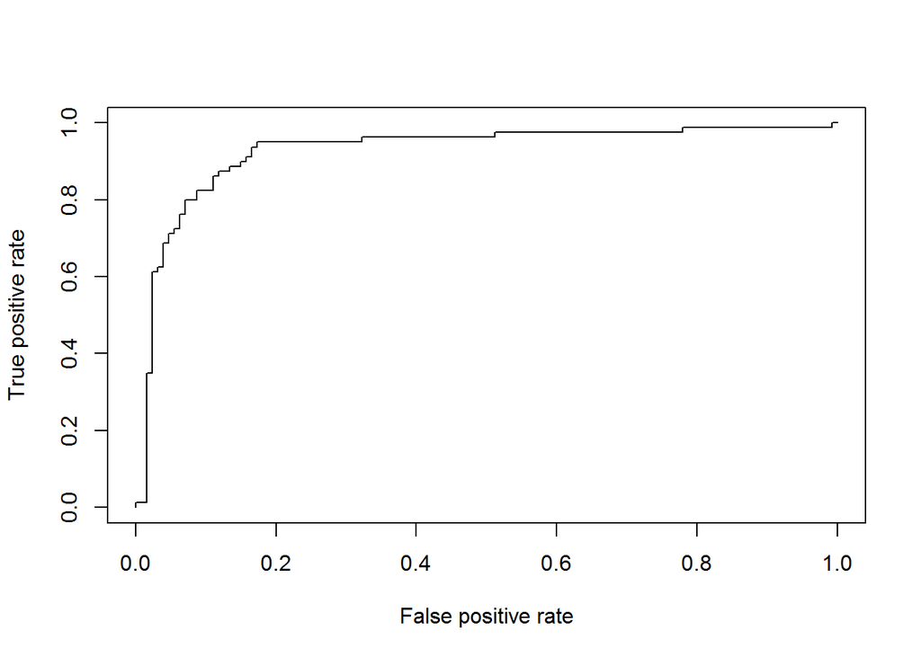

```r
pr <- prediction(predicted, dataTest$V16)
prf <- performance(pr, measure = "tpr", x.measure = "fpr")
plot(prf)
```

The ROC Curve shows the plot high above and also closer to “1” which is good

Lets check the area under the curve accuracy

```r
auc <- performance(pr, measure = "auc")
auc <- auc@y.values[[1]]
auc
```

```
## [1] 0.9265748
```

Hope this gives you a basis for predicting whether or not someone will be approved for a Credit based on some characters (variables) we know about them!